# Exploratory Data Analysis with ggplot2

## read the data

`r`r df <- read.csv(‘weather_2016.csv’, stringsAsFactors = F)

## inspect the data

```r
head(df)
```

|  | date.pretty | date.year | date.mon | date.mday | date.hour | date.min | date.tzname | utcdate.pretty | utcdate.year | utcdate.mon | utcdate.mday | utcdate.hour | utcdate.min | utcdate.tzname | tempm | tempi | dewptm | dewpti | hum | wspdm | wspdi | wgustm | wgusti | wdird | wdire | vism | visi | pressurem | pressurei | … |
| --- | --- | --- | --- | --- | --- | --- | --- | --- | --- | --- | --- | --- | --- | --- | --- | --- | --- | --- | --- | --- | --- | --- | --- | --- | --- | --- | --- | --- | --- | --- |
| 1 | 12:00 AM EEST on April 01, 2016 | 2016 | 4 | 1 | 0 | 0 | Europe/Kiev | 9:00 PM GMT on March 31, 2016 | 2016 | 3 | 31 | 21 | 0 | UTC | 12 | 53.0 | 6 | 43.0 | 59 | 10.8 | 6.7 | NA | NA | 260 | West | 20 | 12.0 | 1014 | 29.94 | … |
| 2 | 12:00 AM EEST on April 01, 2016 | 2016 | 4 | 1 | 0 | 0 | Europe/Kiev | 9:00 PM GMT on March 31, 2016 | 2016 | 3 | 31 | 21 | 0 | UTC | 11 | 51.8 | 6 | 42.8 | 71 | 10.8 | 6.7 | -9999 | -9999 | 250 | WSW | 10 | 6.2 | 1014 | 29.95 | … |
| 3 | 12:30 AM EEST on April 01, 2016 | 2016 | 4 | 1 | 0 | 30 | Europe/Kiev | 9:30 PM GMT on March 31, 2016 | 2016 | 3 | 31 | 21 | 30 | UTC | 11 | 51.8 | 6 | 42.8 | 71 | 14.4 | 8.9 | -9999 | -9999 | 270 | West | 10 | 6.2 | 1014 | 29.95 | … |
| 4 | 1:00 AM EEST on April 01, 2016 | 2016 | 4 | 1 | 1 | 0 | Europe/Kiev | 10:00 PM GMT on March 31, 2016 | 2016 | 3 | 31 | 22 | 0 | UTC | 10 | 50.0 | 7 | 44.6 | 82 | 10.8 | 6.7 | -9999 | -9999 | 230 | SW | 9 | 5.6 | 1013 | 29.92 | … |
| 5 | 1:30 AM EEST on April 01, 2016 | 2016 | 4 | 1 | 1 | 30 | Europe/Kiev | 10:30 PM GMT on March 31, 2016 | 2016 | 3 | 31 | 22 | 30 | UTC | 9 | 48.2 | 8 | 46.4 | 93 | 10.8 | 6.7 | -9999 | -9999 | 220 | SW | 10 | 6.2 | 1013 | 29.92 | … |
| 6 | 2:00 AM EEST on April 01, 2016 | 2016 | 4 | 1 | 2 | 0 | Europe/Kiev | 11:00 PM GMT on March 31, 2016 | 2016 | 3 | 31 | 23 | 0 | UTC | 9 | 48.2 | 8 | 46.4 | 93 | 7.2 | 4.5 | -9999 | -9999 | 270 | West | 10 | 6.2 | 1013 | 29.92 | … |

|  | date.pretty | date.year | date.mon | date.mday | date.hour | date.min | date.tzname | utcdate.pretty | utcdate.year | utcdate.mon | utcdate.mday | utcdate.hour | utcdate.min | utcdate.tzname | tempm | tempi | dewptm | dewpti | hum | wspdm | wspdi | wgustm | wgusti | wdird | wdire | vism | visi | pressurem | pressurei | … |
| --- | --- | --- | --- | --- | --- | --- | --- | --- | --- | --- | --- | --- | --- | --- | --- | --- | --- | --- | --- | --- | --- | --- | --- | --- | --- | --- | --- | --- | --- | --- |
| 20869 | 9:00 PM EEST on September 30, 2016 | 2016 | 9 | 30 | 21 | 0 | Europe/Kiev | 6:00 PM GMT on September 30, 2016 | 2016 | 9 | 30 | 18 | 0 | UTC | 20 | 68.0 | 12 | 53.6 | 60 | 14.4 | 8.9 | -9999 | -9999 | 230 | SW | -9999 | -9999 | 1016 | 30.01 | … |
| 20870 | 9:30 PM EEST on September 30, 2016 | 2016 | 9 | 30 | 21 | 30 | Europe/Kiev | 6:30 PM GMT on September 30, 2016 | 2016 | 9 | 30 | 18 | 30 | UTC | 19 | 66.2 | 12 | 53.6 | 64 | 10.8 | 6.7 | -9999 | -9999 | 230 | SW | -9999 | -9999 | 1016 | 30.01 | … |
| 20871 | 10:00 PM EEST on September 30, 2016 | 2016 | 9 | 30 | 22 | 0 | Europe/Kiev | 7:00 PM GMT on September 30, 2016 | 2016 | 9 | 30 | 19 | 0 | UTC | 19 | 66.2 | 12 | 53.6 | 64 | 10.8 | 6.7 | -9999 | -9999 | 230 | SW | -9999 | -9999 | 1016 | 30.01 | … |
| 20872 | 10:30 PM EEST on September 30, 2016 | 2016 | 9 | 30 | 22 | 30 | Europe/Kiev | 7:30 PM GMT on September 30, 2016 | 2016 | 9 | 30 | 19 | 30 | UTC | 18 | 64.4 | 11 | 51.8 | 64 | 10.8 | 6.7 | -9999 | -9999 | 230 | SW | -9999 | -9999 | 1016 | 30.01 | … |
| 20873 | 11:00 PM EEST on September 30, 2016 | 2016 | 9 | 30 | 23 | 0 | Europe/Kiev | 8:00 PM GMT on September 30, 2016 | 2016 | 9 | 30 | 20 | 0 | UTC | 17 | 62.6 | 12 | 53.6 | 72 | 10.8 | 6.7 | -9999 | -9999 | 240 | WSW | -9999 | -9999 | 1016 | 30.01 | … |
| 20874 | 11:30 PM EEST on September 30, 2016 | 2016 | 9 | 30 | 23 | 30 | Europe/Kiev | 8:30 PM GMT on September 30, 2016 | 2016 | 9 | 30 | 20 | 30 | UTC | 17 | 62.6 | 11 | 51.8 | 68 | 10.8 | 6.7 | -9999 | -9999 | 230 | SW | -9999 | -9999 | 1016 | 30.01 | … |

```r
str(df)
```

```
'data.frame':   20874 obs. of  44 variables:
 $ date.pretty   : chr  "12:00 AM EEST on April 01, 2016" "12:00 AM EEST on April 01, 2016" "12:30 AM EEST on April 01, 2016" "1:00 AM EEST on April 01, 2016" ...
 $ date.year     : int  2016 2016 2016 2016 2016 2016 2016 2016 2016 2016 ...
 $ date.mon      : int  4 4 4 4 4 4 4 4 4 4 ...
 $ date.mday     : int  1 1 1 1 1 1 1 1 1 1 ...
 $ date.hour     : int  0 0 0 1 1 2 2 3 3 3 ...
 $ date.min      : int  0 0 30 0 30 0 30 0 0 30 ...
 $ date.tzname   : chr  "Europe/Kiev" "Europe/Kiev" "Europe/Kiev" "Europe/Kiev" ...
 $ utcdate.pretty: chr  "9:00 PM GMT on March 31, 2016" "9:00 PM GMT on March 31, 2016" "9:30 PM GMT on March 31, 2016" "10:00 PM GMT on March 31, 2016" ...
 $ utcdate.year  : int  2016 2016 2016 2016 2016 2016 2016 2016 2016 2016 ...
 $ utcdate.mon   : int  3 3 3 3 3 3 3 4 4 4 ...
 $ utcdate.mday  : int  31 31 31 31 31 31 31 1 1 1 ...
 $ utcdate.hour  : int  21 21 21 22 22 23 23 0 0 0 ...
 $ utcdate.min   : int  0 0 30 0 30 0 30 0 0 30 ...
 $ utcdate.tzname: chr  "UTC" "UTC" "UTC" "UTC" ...
```

[output cut: 30 more lines]

## lets reduce number of variables

```r
library(dplyr)
df <- df %>%
  select(date.year:date.min, tempm, hum, pressurem, conds, wdire, wdird, wspdm)
```

## we need proper dates

```r
df <- df %>%
  mutate(date = paste(date.year, date.mon, date.mday, sep='-'),
         time = paste(date.hour, date.min, sep = ':'),
         datetime = paste(date, time, sep = ' '),
         datetime = as.POSIXct(strptime(datetime, format = '%Y-%m-%d %H:%M')),
         month = lubridate::month(datetime, label = TRUE, abbr = FALSE))
```

## get seasons

```r
df$season <- case_when(
  df$month %in% c('January', 'February', 'December') ~ 'winter',
  df$month %in% c('March', 'April', 'May') ~ 'spring',
  df$month %in% c('June', 'July', 'August') ~ 'summer',
  df$month %in% c('September', 'October', 'November') ~ 'autumn'
)
df$season <- factor(df$season, ordered = TRUE,
                    levels = c('winter', 'spring', 'summer', 'autumn'))
```

## ok, let’s go exploring

[figure not shown]

## color by season

`r`r ggplot(df, aes(x = tempm, fill = season))+ geom_histogram(binwidth = 1)

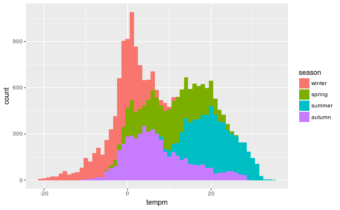

## color by season

`r`r ggplot(df, aes(x = tempm, fill = season))+ geom_density(alpha = 0.3)

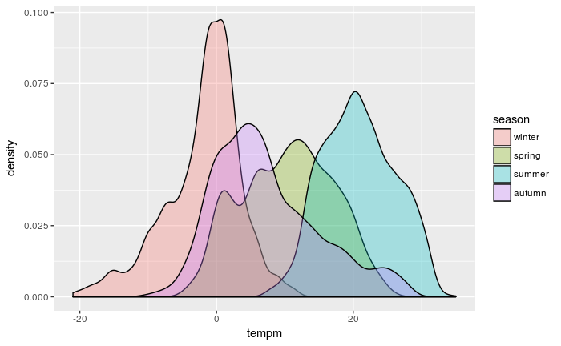

## or lets change representation

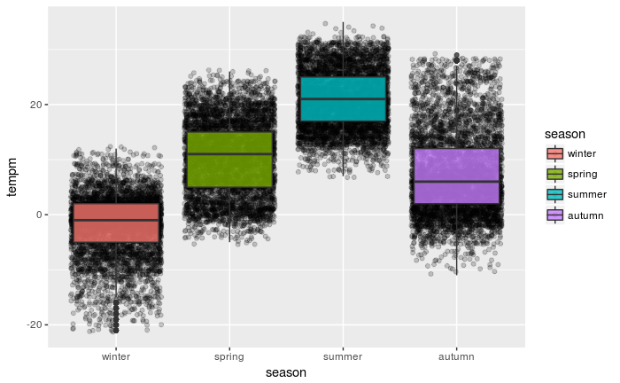

```r
ggplot(df, aes(x = season, y = tempm, fill=season))+
  geom_jitter(alpha=0.2) +
  geom_boxplot(alpha=0.8)
```

```r
NA
```

## once again

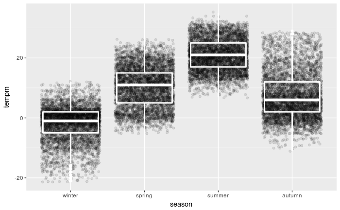

```r
ggplot(df, aes(x = season, y = tempm))+
  geom_jitter(alpha = 0.1)+
  geom_boxplot(fill = NA, color = 'white', size = 1)
```

## and again

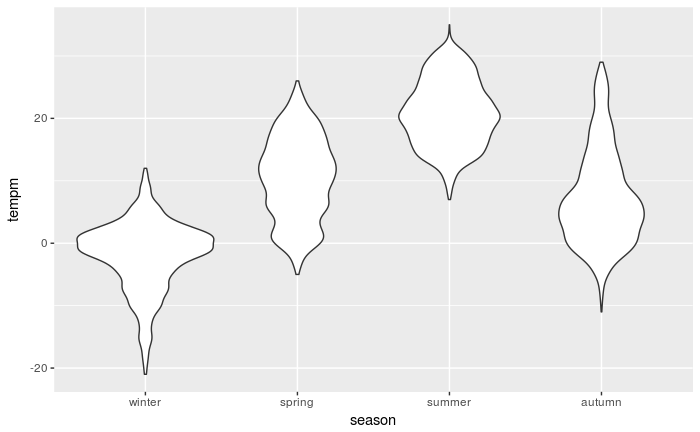

```r
ggplot(df, aes(x = season, y = tempm))+
  geom_violin()
```

## and once more

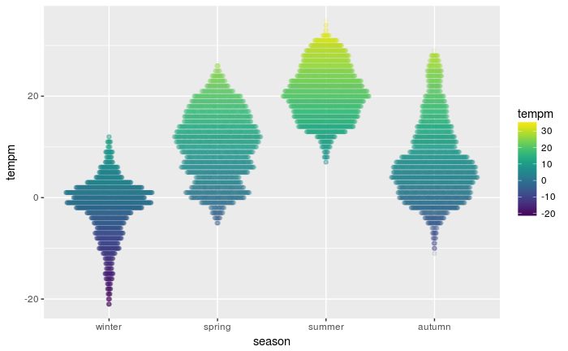

```r
library(ggbeeswarm)
ggplot(df, aes(x = season, y = tempm, color = tempm))+
  geom_quasirandom(alpha = 0.1)+
  viridis::scale_color_viridis()
```

## and once more

`r`r library(ggbeeswarm) ggplot(df, aes(x = month, y = tempm, color = tempm))+ geom_quasirandom(alpha = 0.1)+ viridis::scale_color_viridis()

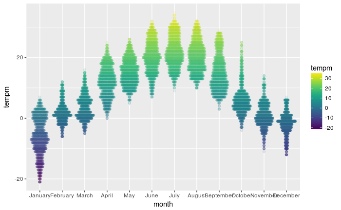

## show variation during the day

`r`r ggplot(df, aes(x = as.Date(datetime), y = time, fill = tempm))+ geom_tile()

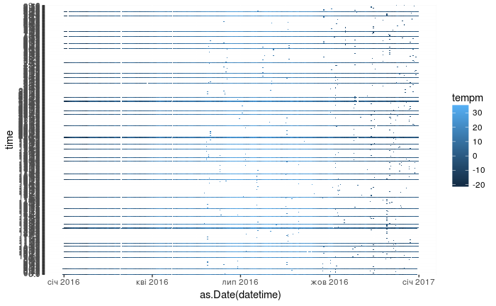

## no, really, show variation during the day

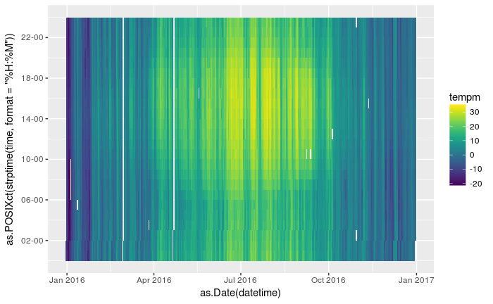

```r
df %>% filter(stringr::str_detect(df$time, '00|30')) %>%
ggplot(aes(x = as.Date(datetime),
               y = as.POSIXct(strptime(time, format = '%H:%M')),
               fill = tempm))+
  geom_tile()+
  scale_y_datetime(date_labels = '%H-%M', date_breaks = '4 hour') +
  viridis::scale_fill_viridis()
```

## can we do it another way? sure we can

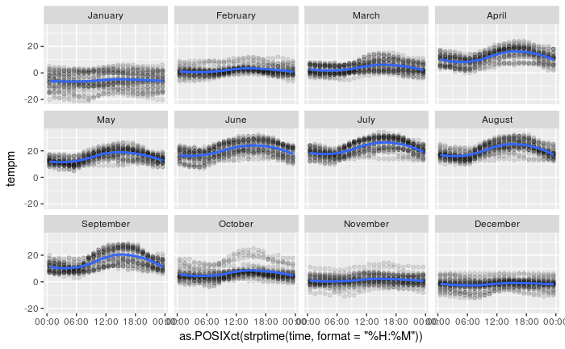

```r
df %>% filter(stringr::str_detect(df$time, '00|30')) %>%
ggplot(aes(x = as.POSIXct(strptime(time, format = '%H:%M')),
           y = tempm))+
  geom_point(alpha=0.1)+  geom_smooth()+
  scale_x_datetime(date_labels = '%H:%M')+
  facet_wrap(~month)
```

## summarise by weather conditions

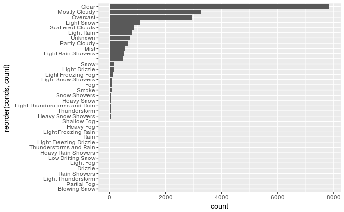

```r
df %>% group_by(conds) %>%
  summarise(count = n()) %>%
  ggplot(aes(x = reorder(conds, count), y = count))+
  geom_bar(stat = 'identity')+
  coord_flip()
```

## show only rainy days

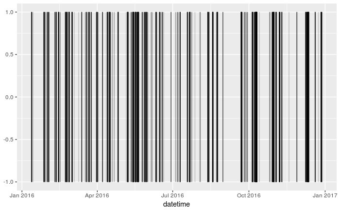

```r
df %>% filter(stringr::str_detect(conds, pattern = 'Rain')) %>%
  ggplot(aes(x = datetime))+
  geom_linerange(aes(ymin = -1, ymax = 1), alpha = 0.2)
```

## show only snowy days

`r`r df %>% filter(stringr::str_detect(conds, pattern = ‘Snow’)) %>% ggplot(aes(x = datetime))+ geom_linerange(aes(ymin = -1, ymax = 1, color = tempm), alpha = 0.2)+ viridis::scale_color_viridis()

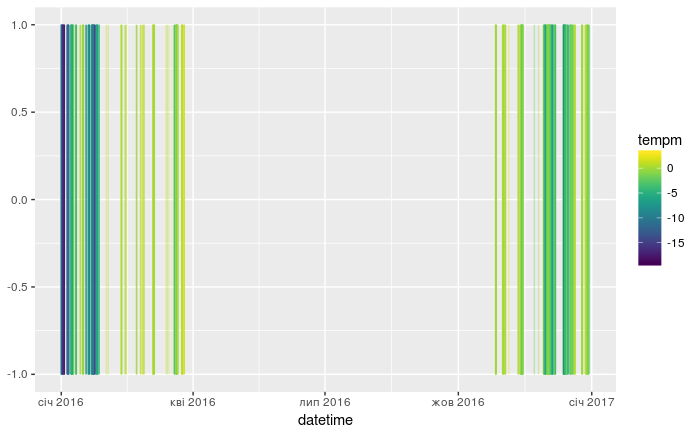

## show ‘clear’ vs ‘cloudy’

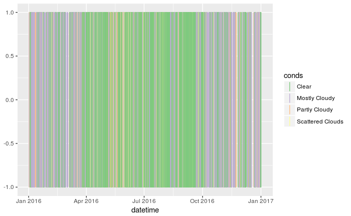

```r
df %>% filter(stringr::str_detect(conds, pattern = 'Clear|Cloud')) %>%
  ggplot(aes(x = datetime))+
  geom_linerange(aes(ymin = -1, ymax = 1, color = conds))+
  scale_color_brewer(type = 'qual')
```

## show ‘clear’ vs ‘cloudy’

`r`r df %>% filter(stringr::str_detect(conds, pattern = ‘Clear|Cloud’)) %>% ggplot(aes(x = datetime))+ geom_linerange(aes(ymin = -1, ymax = 1, color = conds), size = 0.1)+ scale_color_brewer(type = ‘qual’, palette = 2)+ facet_wrap(~conds, ncol = 1)

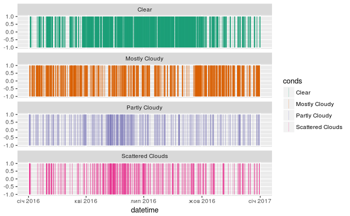

## explore winds data

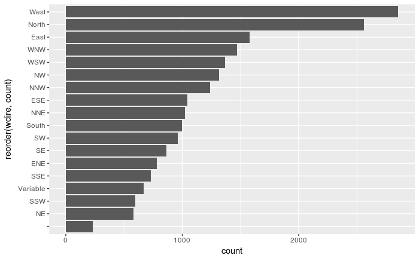

```r
df %>% group_by(wdire) %>%
  summarise(count = n()) %>%
  ggplot(aes(reorder(wdire, count), count))+
  geom_bar(stat = 'identity')+
  coord_flip()
```

## explore winds data

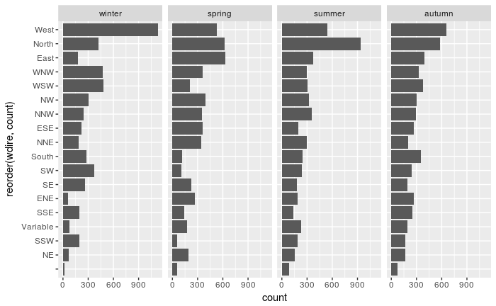

```r
df %>% group_by(wdire, season) %>%
  summarise(count = n()) %>%
  ggplot(aes(reorder(wdire, count), count))+
  geom_bar(stat = 'identity')+
  coord_flip()+
  facet_wrap(~season, ncol = 4)
```

## wind direction by season

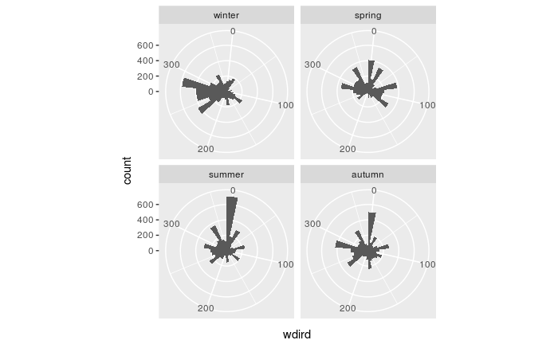

```r
ggplot(df, aes(x = wdird))+
  geom_histogram()+
  facet_wrap(~season) +
  coord_polar()
```

## wind speed by season

`r`r ggplot(df, aes(x = wspdm))+ geom_histogram()+ facet_wrap(~season)

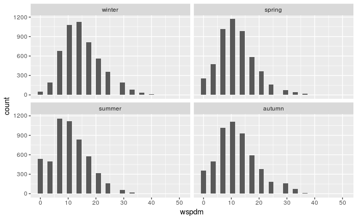

## wind direction vs wind speed

`r`r ggplot(df, aes(x = wdird, y = wspdm))+ geom_point(alpha = 0.25)+ facet_wrap(~season)

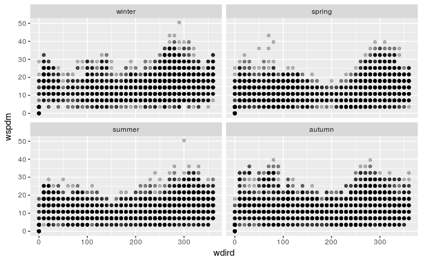

## wind direction vs wind speed

`r`r ggplot(df, aes(x = wdird, y = wspdm))+ geom_count(alpha = 0.5)+ facet_wrap(~season)

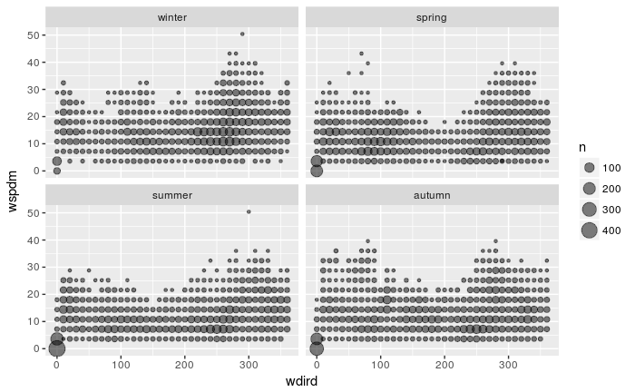

## wind direction vs wind speed

`r`r ggplot(df, aes(x = wdird, y = wspdm))+ geom_count(aes(color = ..n..), alpha = 1)+ viridis::scale_color_viridis(option = ‘magma’, direction = -1)+ facet_wrap(~season)

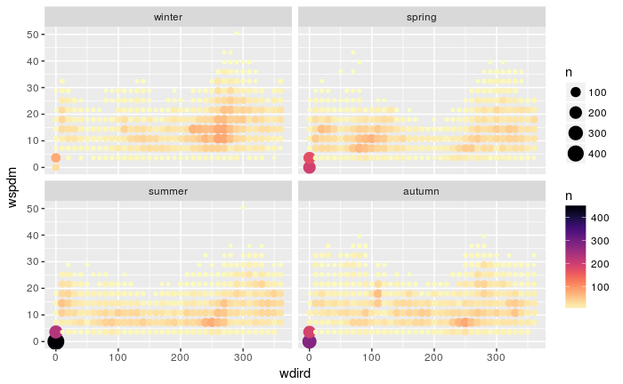

## wind direction vs wind speed

`r`r ggplot(df, aes(x = wdire, y = wspdm))+ geom_count(aes(color = ..n..), alpha = 1)+ viridis::scale_color_viridis(option = ‘magma’, direction = -1)+ coord_flip()+ facet_wrap(~season)

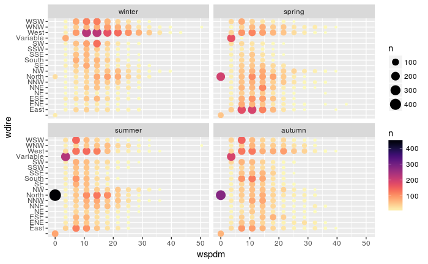

## wind speed by month

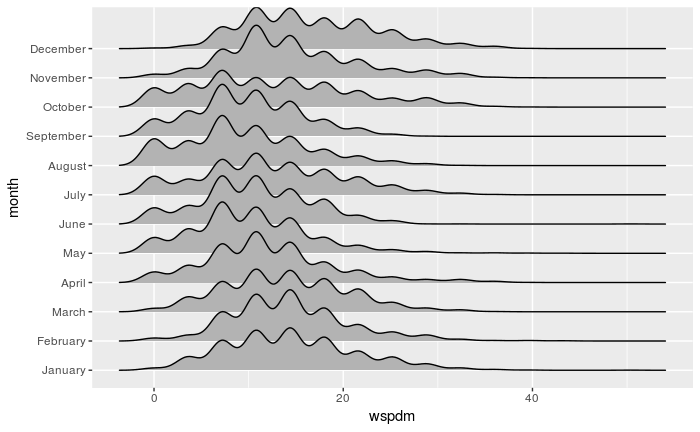

```r
library(ggjoy)
ggplot(df, aes(x = wspdm, y = month))+
  geom_joy()
```

## wind speed by month

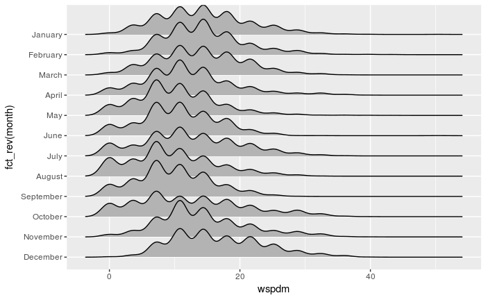

```r
library(forcats)
ggplot(df, aes(x = wspdm, y = fct_rev(month)))+
  geom_joy()
```

## daily means

`r`r df %>% mutate(date = as.Date(datetime)) %>% group_by(date) %>% summarise(temp_avg = mean(tempm, na.rm = T)) %>% ggplot(aes(x = date, y = temp_avg))+ geom_line()

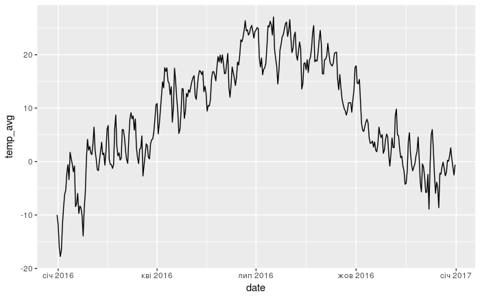

## daily ranges

`r`r df %>% mutate(date = as.Date(datetime)) %>% group_by(date) %>% summarise(temp_min = min(tempm, na.rm = T), temp_max = max(tempm, na.rm = T), temp_avg = mean(tempm, na.rm = T)) %>% ggplot(aes(x = date))+ geom_linerange(aes(ymin = temp_min, ymax = temp_max))

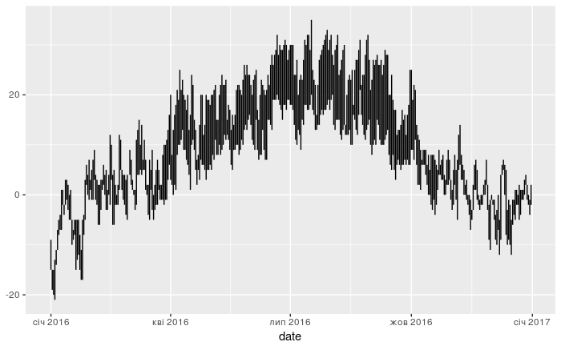

## daily ranges and daily means

`r`r df %>% mutate(date = as.Date(datetime)) %>% group_by(date) %>% summarise(temp_min = min(tempm, na.rm = T), temp_max = max(tempm, na.rm = T), temp_avg = mean(tempm, na.rm = T)) %>% ggplot(aes(x = date))+ geom_linerange(aes(ymin = temp_min, ymax = temp_max), color = ‘gray’, alpha = 0.7)+ geom_line(aes(y = temp_avg), color = ‘darkcyan’, size = 0.5)

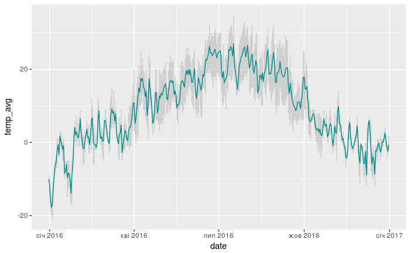

## daily ranges and daily means

`r`r df %>% mutate(date = as.Date(datetime)) %>% group_by(date) %>% summarise(temp_min = min(tempm, na.rm = T), temp_max = max(tempm, na.rm = T), temp_avg = mean(tempm, na.rm = T)) %>% ggplot(aes(x = date))+ geom_ribbon(aes(ymin = temp_min, ymax = temp_max), fill = ‘gray’, alpha = 0.7)+ geom_line(aes(y = temp_avg), color = ‘darkcyan’, size = 0.3)

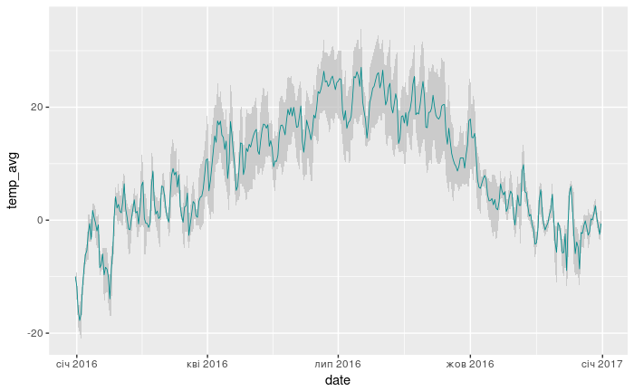

## temp vs humidity

`r`r ggplot(df, aes(hum, tempm))+ geom_jitter()

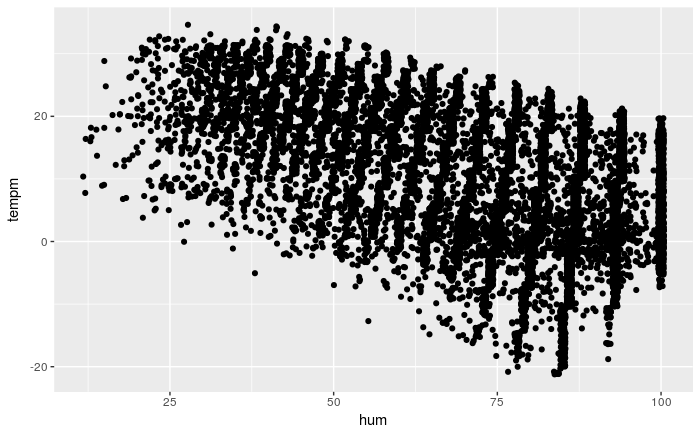

`r`r ggplot(df, aes(pressurem, tempm))+ geom_jitter()

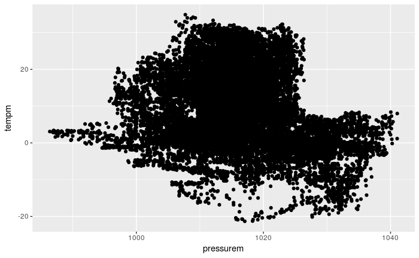